# Historia del Pensamiento y del Análisis Económico

U2. Desde los inicios hasta fines de la Edad Media

Sebastián Freille

Facultad de Ciencias Económicas, UNC

2026-08-14

# **El pensamiento económico antes del capitalismo**

## ¿Economía antes del capitalismo?

“Wealth consists not in having great possessions but in having few wants.”  
**[Epicteto]**

- Durante milenios, la “economía” no era una disciplina separada
- Los pensadores antiguos se preocupaban por las **consecuencias** de la actividad económica — justicia, virtud — más que por sus **causas**
- No había marco científico en el sentido moderno

## ¿Por qué nos importa este período?

- Aquí nacen conceptos que **todavía usamos**: valor, precio justo, dinero, división del trabajo
- La estructura económica básica **no cambió radicalmente hasta el siglo XV**
- Las preocupaciones éticas sobre la economía **nunca desaparecieron** $\longrightarrow$ pensemos en debates actuales sobre desigualdad, usura financiera, comercio justo

## La concepción antigua de la riqueza

| **Antigüedad** | **Modernidad** |
| --- | --- |
| Riqueza = tener pocas necesidades | Riqueza = acumulación de bienes |
| Actividad económica subordinada a la ética | Ética subordinada (¿o ignorada?) en economía |
| El lucro es sospechoso | El lucro es legítimo y deseable |
| No hay “economía” como campo separado | Economía como ciencia autónoma |

## Ubicación temporal

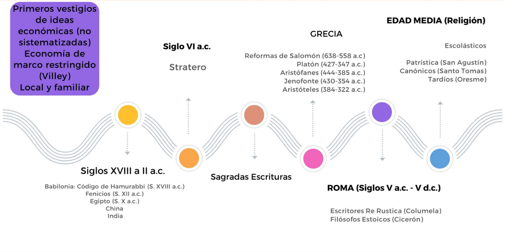

Línea de tiempo mostrando las principales etapas del pensamiento económico antiguo y medieval

# **Contexto y características del período**

## La actividad económica en el mundo antiguo

- **Economía de autosuficiencia**: pocas interacciones, casi sin mercados
- **Asignación centralizada**: la autoridad gobernante decidía
- **Propiedad privada limitada**: existía pero con restricciones importantes
- **Esclavitud generalizada**: la mano de obra no era “libre”

A diferencia de los últimos dos siglos, los pensadores antiguos se preocuparon por las **consecuencias morales** de la actividad económica.

## De la sociedad tribal a la sociedad de clases

**Sociedades primitivas y tribales**

- Propiedad comunal
- Actividad económica básica de subsistencia
- No hay disociación entre producción y producto

**Sociedades de clases y castas**

- Aparece la propiedad privada
- Actividad económica más compleja
- Surgen tensiones y problemas distributivos

## Los dos grandes temas del período

1. **No especialización del análisis social**
   - La actividad económica no se separa de lo político, lo social, lo moral
   - Esto fue constante en autores de diversas épocas y tradiciones
2. **Énfasis en cuestiones filosóficas y éticas**
   - La motivación para estudiar comercio y precios era **evaluar su justicia**
   - La administración pública se discutía dentro de un marco ético

## Tres tradiciones fundamentales

Siguiendo a **Lowry (2003)**, el pensamiento económico antiguo y medieval puede estructurarse en:

| Tradición | Enfoque | Ejemplos |
| --- | --- | --- |
| **Administrativa** | Gestión estatal | Egipto, Mesopotamia, China |
| **Moral** | Religión y ética | Profetas hebreos, **Aristóteles**, escolásticos |
| **Analítica** | Valor, intercambio, especialización | **Aristóteles**, algunos escolásticos |

# **La tradición administrativa**

## Las civilizaciones fluviales [circa 2500 a.C.]

- **Egipto y Mesopotamia**: primeros registros de organización económica formal
  - Agricultura coordinada con inundaciones anuales
  - Graneros estatales y contabilidad centralizada
  - Necesidad de **medición de tierras y regulación pública**
- **Tablas de Erlenmeyer** (2200 a.C., Sumeria)
  - Registros de producción agrícola y eficiencia laboral
  - Sistema sexagesimal para cálculos administrativos

## La monarquía hebrea [1047-722 a.C.]

- Período de monarquía unida y dividida
- Introducción de propiedad privada y comercio
- Primera posibilidad documentada de **acumulación**
- Sociedad con marcada división ricos/pobres
- Los profetas condenaban los excesos de las nuevas clases

Aquí aparece por primera vez una **clase desposeída** y la crítica moral a la desigualdad.

## El pensamiento griego: características

- **Visión antropocéntrica**: la economía es administración del hogar (*oikonomía*)
- **Intercambio como mecanismo aislado**: economía básica y simple
- **Exaltación de artes militares y agricultura**; desprecio por trabajo y comercio
- **Prevalencia de consideraciones morales y éticas**
- Sociedad “congelada”: poco rol del emprendedor y la creatividad

## La división del trabajo en Platón

“No somos todos iguales; hay muchas diversidades de naturaleza entre nosotros que se adaptan a diferentes ocupaciones.”  
**[Platón]**

- Las diferencias entre individuos son **originarias, no adquiridas**
- Dado que individuos diferentes producen bienes diferentes:
  - La especialización fundamenta el comercio
  - La especialización es el fundamento económico de la *polis*

## Platón: la división del trabajo

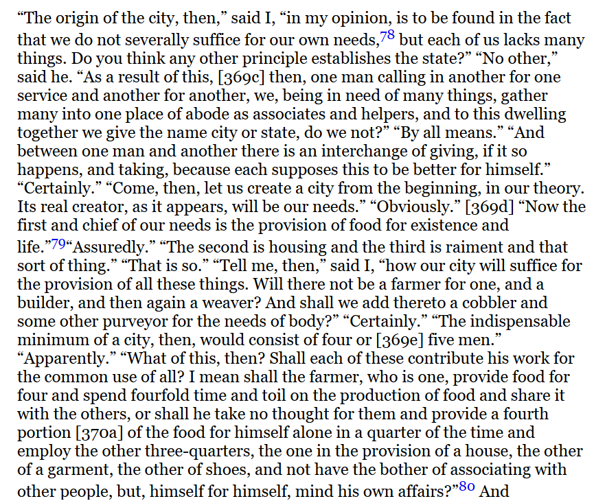

## Platón y el comercio

- **Despreciaba el uso de oro y plata como moneda** $\longrightarrow$ amenaza a la regulación económica y moral
- Abogaba por mantener la población constante (¡5040 ciudadanos!)
- Poco espacio para innovación, dinámica empresaria y crecimiento económico

Para Platón, la sociedad ideal debía ser **rígida y estática**. El cambio era visto como regresivo.

## China: la tradición oriental

- Entre 771 y 249 a.C. hubo una revolución del pensamiento económico en China
- Cuatro escuelas: confucianistas, moístas, taoístas, legalistas
- **Guan Zhong (720-645 a.C.)**: filosofía del *Qing Zhong* (ligero/pesado)

“Cuando las cosas son abundantes, serán baratas; cuando son escasas, serán caras.”  
**[Guan Zhong]**

Idea primitiva de **oferta y demanda** y valor relativo de todos los bienes.

## Guan Zhong: anticipaciones notables

- Anticipó la **escasez como determinante del precio**
- Demanda como depósito de valor: si un bien “se guarda bajo llave”, su precio tiende a subir
- Idea sobre **estructura de mercado**: bienes concentrados son “pesados”; dispersos son “ligeros”
- **Política fiscal contracíclica**: el gobierno debía comprar cuando los bienes eran “ligeros” y vender cuando eran “pesados”

## India: la “ciencia de la riqueza”

- Imperio Maurya (322-185 a.C.)
- **Kautilya (Chanakya)**: *Arthashastra* (“ciencia de la riqueza”)
  - Tratado sobre economía y política
  - El Estado juega rol vital en mantener el bienestar material
- **Política económica activa** y control estatal significativo
- La persecución de ganancia no era incompatible con vida moral

# **Aristóteles: entre lo moral y lo analítico**

## Aristóteles: la figura dominante

- **Aristóteles (384-322 a.C.)**: la figura más influyente del período
- Discípulo (y antagonista) de Platón
- Dos grandes obras sobre el tema: *Ética* y *Política*
- Su pensamiento filosófico lo hizo preocuparse por **lo natural** y **lo justo**

“Platón es mi amigo, pero más amiga es la verdad.”

## Aristóteles y la propiedad privada

A diferencia de **Platón**, **favoreció la propiedad privada**:

1. Es **más productiva** que la comunal
2. La propiedad comunal genera **conflictos**
3. Está implantada en la **naturaleza humana**
4. Ha existido **siempre y en todos lados**

Postuló que sólo la propiedad privada le provee al individuo la **oportunidad de actuar moralmente** — i.e. practicar las virtudes de la benevolencia y filantropía.

## La crematística

- **Aristóteles** distinguió entre:
  - **Economía natural** (*oikonomía*): satisfacer necesidades básicas
  - **Economía antinatural** (*chrematistiké*): acumulación de riqueza

“En el intercambio natural, el dinero es un medio para un fin; en el intercambio artificial, el dinero es tanto un medio como un fin.”

Rechazó el intercambio artificial porque implicaba ganar dinero por sí mismo.

## Aristóteles y el dinero

Comprendió las **tres funciones del dinero**:

1. Patrón de valor
2. Medio de cambio
3. Depósito de valor

Pero **condenó moralmente el préstamo de dinero** (usura).

Aquí vemos la contradicción entre lo analítico y lo moral que caracteriza a todo el período.

## Valor en uso vs. valor en cambio

“Las cosas que tienen gran valor en uso frecuentemente apenas tienen valor en cambio; y las que tienen gran valor en cambio apenas tienen valor en uso.”

- **Aristóteles** **distinguió** entre valor de uso y valor en cambio
- Sugirió que el segundo deriva del primero
- Pero **no ofreció teoría del precio**
- Foco en el problema ético de la **justicia en el intercambio**

## El principio de reciprocidad

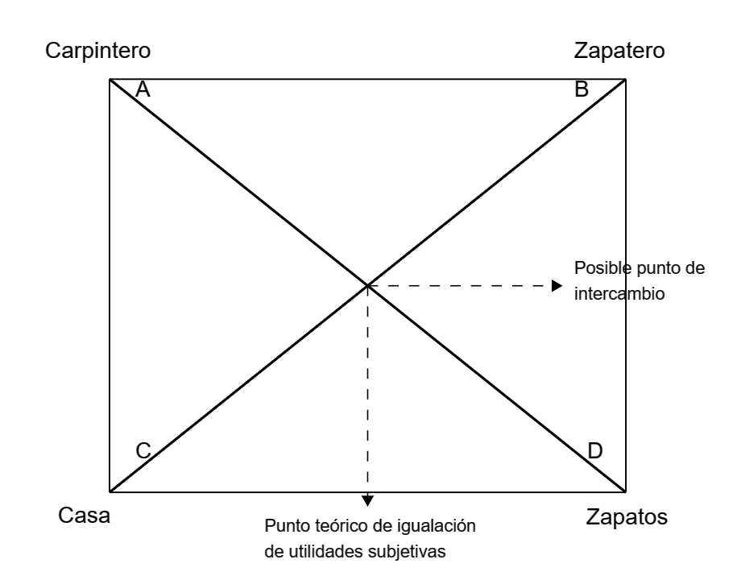

Diagrama del principio aristotélico de reciprocidad en el intercambio

## Aristóteles: evaluación

| **Logros** | **Limitaciones** |
| --- | --- |
| Distinción uso/cambio | No hay teoría del valor |
| Funciones del dinero | Confusión moral/analítica |
| División del trabajo | Condena de usura |
| Defensa propiedad privada | Sociedad estática |

Aristóteles ofrece ideas y discusiones aisladas, pero no una teoría del valor y/o distribución.

# **El “gran vacío” y el mundo islámico**

## La tesis de Schumpeter

“En lo que respecta a nuestro tema, podemos saltar 500 años hasta Santo Tomás de Aquino.”  
**[Joseph Schumpeter, 1954]**

- **Schumpeter** minimizó las contribuciones entre la caída de Grecia y el siglo XIII
- Esta tesis ha sido **cuestionada recientemente**
- Hubo contribuciones importantes del **mundo islámico**

## Ibn Jaldún (1332-1406)

- Historiador, sociólogo y economista árabe
- **Anticipó varias teorías económicas modernas**:
  - Teoría del valor-trabajo
  - División del trabajo y especialización
  - Determinación de precios por oferta y demanda
  - Oposición a impuestos excesivos
  - Naturaleza cíclica del crecimiento económico

La prosperidad económica depende del grado de **cohesión social**, el cual disminuye a medida que las sociedades se vuelven más ricas.

## Roma: el legado jurídico

- Gran contribución del imperio romano no económica $\longrightarrow$ **el derecho**
- El *ius gentium* suministró marco legal para la actividad económica contemporánea y posterior
- Pensamiento cristiano primitivo se centró en el recto uso de bienes materiales (moral)

Llamativa **ausencia de pensamiento económico** durante la Roma Republicana e Imperial y durante la Cristiandad temprana.

# **La escolástica y el pensamiento medieval**

## El contexto medieval europeo

- **Feudalismo**: sistema de producción basado en propiedad de la tierra
- **Servidumbre**: trabajadores atados a la tierra
- **Economía de autosuficiencia**: comercio limitado o prohibido
- Transición lenta hacia el mercado como fenómeno de la vida diaria

## Los escolásticos: método y preocupaciones

- **Tradición escolástica**: preservar y desarrollar ideas aristotélicas
- **Método**: formular un tema, examinar opiniones contrarias, producir documento
- Basado en fe y peso de autoridad
- Principal interés: la **justicia**, no el intercambio

“We next have to consider the sins which have to do with voluntary exchanges…”  
**[Santo Tomás de Aquino, *Summa Theologica*]**

## Santo Tomás de Aquino (1225-1274)

- Principal figura del movimiento escolástico
- Obra clave: *Summa Theologica*
- Centro de la discusión: el **precio justo**

**Precio justo**

Precio que, considerando el trabajo incorporado, permite mantener el *status* en la jerarquía social. Los gremios debían velar por el cobro del precio justo.

## Santo Tomás y el intercambio

- Si el precio de mercado es competitivo $\longrightarrow$ es justo
- Pero condenó precios de monopolio
- Valor justo es “objetivo” solo en el sentido de que individuos no pueden alterarlo
- Retoma a **Aristóteles** pero no resuelve la determinación del valor

Argumenta que no es “un pecado” vender al precio vigente aún sabiendo que hay más vendedores potenciales entrando al mercado.

## San Bernardino de Siena (1380-1444)

- A diferencia de **Santo Tomás**, encuentra útil el comercio y la industria
- Sigue a **Aristóteles** sobre propiedad privada
- Ofreció **tres elementos que determinan el valor**:
  1. Utilidad *intrínseca* del objeto
  2. Escasez del objeto
  3. Deseabilidad del objeto

## La paradoja del valor en San Bernardino

“De otra manera, un vaso de agua sería prácticamente impagable… pero es abundante.”

- El precio se determina por **estimación colectiva** (valuación de mercado)
- Anticipación de la teoría de la **utilidad marginal**
- Condena las prácticas monopólicas
- Las reglas de precios aplican también a salarios

## El interés y la usura

- **Condena casi total de la usura** entre los escolásticos
- Discusión en la *Summa Theologica*, Pregunta 78
- La oposición no era a la ganancia de sociedades
- Era **inflexible** respecto del interés sobre préstamos de dinero

**Excepciones toleradas**:

- *Damnum emergens* (daño emergente)
- *Lucrum cessans* (lucro cesante)

## ¿Por qué condenaban la usura?

“Si un hombre quisiera vender vino y el uso del vino por separado, estaría vendiendo lo mismo dos veces, o vendiendo lo que no existe.”  
**[Santo Tomás de Aquino]**

- El dinero se “consume” al usarse (como el vino)
- A diferencia de una casa, cuyo uso no la destruye
- Por lo tanto, cobrar por el “uso” del dinero es injusto

# **Valoración e importancia**

## Contribuciones al desarrollo de la economía

**Conceptos que perduran**:

- Distinción **valor en uso / valor en cambio**
- **Funciones del dinero**
- **División del trabajo**
- **Precio justo** (antecedente del precio de equilibrio)

**Limitaciones metodológicas**:

- No separación de economía positiva y normativa
- Ausencia de análisis sistemático de causa-efecto
- Condena moral que obstruye análisis

## Validez a través del tiempo

| Concepto | Antigüedad | Actualidad |
| --- | --- | --- |
| División del trabajo | **Platón**, **Aristóteles** | Microeconomía, comercio internacional |
| Funciones del dinero | **Aristóteles** | Teoría monetaria |
| Precio justo | Escolásticos | Debates sobre precios predatorios, comercio justo |
| Usura | Condena moral | Regulación de tasas de interés |

## Caminos abiertos y cerrados

**Ideas que abrieron caminos**:

- El intercambio puede generar ganancias mutuas (**Aristóteles**)
- La especialización aumenta la productividad (**Platón**)
- Los precios reflejan escasez y utilidad (**San Bernardino**)

**Ideas que cerraron caminos**:

- La riqueza es un juego de suma cero
- El comercio y el lucro son moralmente sospechosos
- La usura debe prohibirse absolutamente

# **Preguntas para reflexionar**

## Tres preguntas para pensar

1. **¿Por qué tardó tanto en surgir una “ciencia económica” separada de la moral?**
2. **¿Tiene sentido hablar de “precio justo” hoy?** ¿En qué contextos?
3. **¿La condena de la usura era simplemente ignorancia o reflejaba algo más profundo?**

# **Bibliografía**

## Lecturas principales

- **Ekelund, R.B. y Hébert, R.F. (2005).** *Historia de la teoría económica y de su método*. Capítulos 1-2.
- **Roncaglia, A. (2006).** *La riqueza de las ideas*. Capítulo 2.
- **Schumpeter, J.A. (1954).** *History of Economic Analysis*. Part II, Capítulos 1-2.
- **Lowry, S.T. (2003).** Ancient and Medieval Economics. En *A Companion to the History of Economic Thought*.

## Lecturas complementarias

- **Langholm, O. (1998).** *The Legacy of Scholasticism in Economic Thought*.
- **Rothbard, M. (1995).** *Economic Thought Before Adam Smith*. Capítulos 1-4.
- **Gordon, B. (1975).** *Economic Analysis Before Adam Smith*.